# Generalized Linear Mixed Models

Based on C. Manning, 2007 paper

HoxoMaxwell

2019-11-16

This notebook is the followup study of  
https://nlp.stanford.edu/manning/courses/ling289/GLMM.pdf

# 1 Load Library

```r
library(languageR)
library(DT)
library(summarytools)
library(tidyverse)
library(lme4)
library(lmerTest)
```

# 2 Load Data

```r
data("dative")
datatable(
  dative,
  options = list(pageLength = 10,
                 autoWidth = TRUE,
                 scrollX = TRUE,
                 columnDefs = list(
                   list(width = '75px',
                        targets = seq(1, dim(dative)[2])))),
  class = 'cell-border stripe'
  )
```

|  | Speaker | Modality | Verb | SemanticClass | LengthOfRecipient | AnimacyOfRec | DefinOfRec | PronomOfRec | LengthOfTheme | AnimacyOfTheme | DefinOfTheme | PronomOfTheme | RealizationOfRecipient | AccessOfRec | AccessOfTheme |
| --- | --- | --- | --- | --- | --- | --- | --- | --- | --- | --- | --- | --- | --- | --- | --- |
| 1 |  | written | feed | t | 1 | animate | definite | pronominal | 14 | inanimate | indefinite | nonpronominal | NP | given | new |
| 2 |  | written | give | a | 2 | animate | definite | nonpronominal | 3 | inanimate | indefinite | nonpronominal | NP | given | new |
| 3 |  | written | give | a | 1 | animate | definite | nonpronominal | 13 | inanimate | definite | nonpronominal | NP | given | new |
| 4 |  | written | give | a | 1 | animate | definite | pronominal | 5 | inanimate | indefinite | nonpronominal | NP | given | new |
| 5 |  | written | offer | c | 2 | animate | definite | nonpronominal | 3 | inanimate | definite | nonpronominal | NP | given | new |
| 6 |  | written | give | a | 2 | animate | definite | nonpronominal | 4 | inanimate | indefinite | nonpronominal | NP | given | new |
| 7 |  | written | pay | t | 2 | animate | definite | nonpronominal | 4 | inanimate | indefinite | nonpronominal | NP | given | new |
| 8 |  | written | bring | a | 1 | animate | definite | pronominal | 1 | inanimate | indefinite | nonpronominal | NP | given | new |
| 9 |  | written | teach | a | 1 | animate | definite | pronominal | 11 | inanimate | indefinite | nonpronominal | NP | given | accessible |
| 10 |  | written | give | a | 1 | animate | definite | pronominal | 2 | inanimate | indefinite | nonpronominal | NP | given | accessible |

[output cut: 3253 more lines]

- Speaker: factor  
  coding speaker; available only for the subset of spoken English.
- Modality: factor  
  with levels spoken, written.
- Verb: factor  
  with the verbs as levels.
- SemanticClass: factor  
  with levels a (abstract: ‘give it some thought’), c (communication: ‘tell, give me your name’), f (future transfer of possession: ‘owe, promise’), p (prevention of possession: ‘cost, deny’), and t (transfer of possession: ‘give an armband, send’).
- LengthOfRecipient: numeric  
  vector coding the number of words comprising the recipient.
- AnimacyOfRec: factor  
  with levels animate and inanimate for the animacy of the recipient.
- DefinOfRec: factor  
  with levels definite and indefinite coding the definiteness of the recipient.
- PronomOfRec: factor  
  with levels nonpronominal and pronominal coding the pronominality of the recipient.
- LengthOfTheme: numeric  
  vector coding the number of words comprising the theme.
- AnimacyOfTheme: factor  
  with levels animate and inanimate coding the animacy of the theme.
- DefinOfTheme: factor  
  with levels definite and indefinite coding the definiteness of the theme.
- PronomOfTheme: factor  
  with levels nonpronominal and pronominal coding the pronominality of the theme.
- RealizationOfRecipient: factor  
  with levels NP and PP coding the realization of the dative.
- AccessOfRec: factor  
  with levels accessible, given, and new coding the accessibility of the recipient.
- AccessOfTheme: factor  
  with levels accessible, given, and new coding the accessibility of the theme.

# 3 EDA

```r
dfSummary(dative, plain.ascii = F, style = "grid", graph.magnif = .75)
```

### 3.0.1 Data Frame Summary

#### 3.0.1.1 dative

**Dimensions:** 3263 x 15  
**Duplicates:** 188

| No | Variable | Stats / Values | Freqs (% of Valid) | Graph | Valid | Missing |
| --- | --- | --- | --- | --- | --- | --- |
| 1 | Speaker [factor] | 1. S0 2. S1000 3. S1001 4. S1002 5. S1004 6. S1005 7. S1007 8. S1008 9. S1010 10. S1011 [ 414 others ] | 6 ( 0.3%) 1 ( 0.0%) 1 ( 0.0%) 15 ( 0.6%) 1 ( 0.0%) 10 ( 0.4%) 10 ( 0.4%) 1 ( 0.0%) 13 ( 0.6%) 8 ( 0.3%) 2294 (97.2%) | IIIIIIIIIIIIIIIIIII | 2360 (72.33%) | 903 (27.67%) |
| 2 | Modality [factor] | 1. spoken 2. written | 2360 (72.3%) 903 (27.7%) | IIIIIIIIIIIIII IIIII | 3263 (100%) | 0 (0%) |
| 3 | Verb [factor] | 1. accord 2. afford 3. allocate 4. allot 5. allow 6. assess 7. assign 8. assure 9. award 10. bequeath [ 65 others ] | 1 ( 0.0%) 1 ( 0.0%) 3 ( 0.1%) 3 ( 0.1%) 13 ( 0.4%) 1 ( 0.0%) 4 ( 0.1%) 2 ( 0.1%) 19 ( 0.6%) 1 ( 0.0%) 3215 (98.5%) | IIIIIIIIIIIIIIIIIII | 3263 (100%) | 0 (0%) |
| 4 | SemanticClass [factor] | 1. a 2. c 3. f 4. p 5. t | 1433 (43.9%) 405 (12.4%) 59 ( 1.8%) 228 ( 7.0%) 1138 (34.9%) | IIIIIIII II I IIIIII | 3263 (100%) | 0 (0%) |
| 5 | LengthOfRecipient [integer] | Mean (sd) : 1.8 (2.1) min < med < max: 1 < 1 < 31 IQR (CV) : 1 (1.1) | 20 distinct values | : : : : : | 3263 (100%) | 0 (0%) |
| 6 | AnimacyOfRec [factor] | 1. animate 2. inanimate | 3024 (92.7%) 239 ( 7.3%) | IIIIIIIIIIIIIIIIII I | 3263 (100%) | 0 (0%) |
| 7 | DefinOfRec [factor] | 1. definite 2. indefinite | 2775 (85.0%) 488 (15.0%) | IIIIIIIIIIIIIIIII II | 3263 (100%) | 0 (0%) |
| 8 | PronomOfRec [factor] | 1. nonpronominal 2. pronominal | 1229 (37.7%) 2034 (62.3%) | IIIIIII IIIIIIIIIIII | 3263 (100%) | 0 (0%) |
| 9 | LengthOfTheme [integer] | Mean (sd) : 4.3 (4.4) min < med < max: 1 < 3 < 46 IQR (CV) : 3 (1) | 36 distinct values | : : : : : : . | 3263 (100%) | 0 (0%) |
| 10 | AnimacyOfTheme [factor] | 1. animate 2. inanimate | 74 ( 2.3%) 3189 (97.7%) | IIIIIIIIIIIIIIIIIII | 3263 (100%) | 0 (0%) |
| 11 | DefinOfTheme [factor] | 1. definite 2. indefinite | 929 (28.5%) 2334 (71.5%) | IIIII IIIIIIIIIIIIII | 3263 (100%) | 0 (0%) |
| 12 | PronomOfTheme [factor] | 1. nonpronominal 2. pronominal | 2842 (87.1%) 421 (12.9%) | IIIIIIIIIIIIIIIII II | 3263 (100%) | 0 (0%) |
| 13 | RealizationOfRecipient [factor] | 1. NP 2. PP | 2414 (74.0%) 849 (26.0%) | IIIIIIIIIIIIII IIIII | 3263 (100%) | 0 (0%) |
| 14 | AccessOfRec [factor] | 1. accessible 2. given 3. new | 615 (18.9%) 2302 (70.5%) 346 (10.6%) | III IIIIIIIIIIIIII II | 3263 (100%) | 0 (0%) |
| 15 | AccessOfTheme [factor] | 1. accessible 2. given 3. new | 1742 (53.4%) 502 (15.4%) 1019 (31.2%) | IIIIIIIIII III IIIIII | 3263 (100%) | 0 (0%) |

## 3.1 Extract Subset

```r
spdative <- dative %>% filter(Modality == "spoken")
```

## 3.2 xtabs and mosaicplot

```r
spdative.xtabls <- xtabs(
    formula =  ~ RealizationOfRecipient + AnimacyOfTheme + AnimacyOfRec,
    data = spdative
    )
spdative.xtabls
```

```
## , , AnimacyOfRec = animate
##
##                       AnimacyOfTheme
## RealizationOfRecipient animate inanimate
##                     NP      17      1761
##                     PP      46       378
##
## , , AnimacyOfRec = inanimate
##
##                       AnimacyOfTheme
## RealizationOfRecipient animate inanimate
##                     NP       0        81
##                     PP       5        72
```

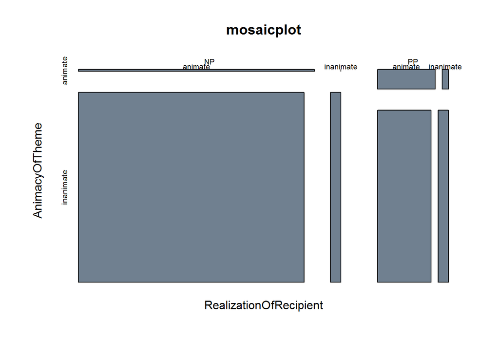

```r
mosaicplot(spdative.xtabls,
           main = "mosaicplot",
           color="slategray")
```

# 4 FE

```r
spdative <- spdative %>%
    mutate(LengthOfThemeMinusRecipient = LengthOfTheme - LengthOfRecipient) %>%
    mutate(RatioOfLengthsThemeOverRecipient = LengthOfTheme / LengthOfRecipient)
```

```r
divs1 <- c(0, 1, 2, 3, 4, 5, 6, 10, 100)
divs2 <- c(-40, -6, -4, -3, -2, -1, 0, 1, 2, 3, 4, 6, 40)
divs3 <- c(-2.5, -1.5, -1, -0.5, -0.25, 0, 0.5, 1, 1.5, 2, 2.5, 4)
recip.leng.group <- cut(spdative$LengthOfRecipient, divs1)
theme.leng.group <- cut(spdative$LengthOfTheme, divs1)
theme.minus.recip.group <- cut(spdative$LengthOfThemeMinusRecipient, divs2)
log.theme.over.recip.group <-
    cut(log(spdative$RatioOfLengthsThemeOverRecipient), divs3)
recip.leng.table <- table(recip.leng.group,
                          spdative$RealizationOfRecipient)
recip.leng.table
```

```
##
## recip.leng.group   NP   PP
##         (0,1]    1687  228
##         (1,2]     133  139
##         (2,3]      19   61
##         (3,4]       8   24
##         (4,5]       4   12
##         (5,6]       4    8
##         (6,10]      3   23
##         (10,100]    1    6
```

# 5 GLMM

## 5.1 Fit1

```r
dative.glmm1 <- glmer(
    formula = RealizationOfRecipient ~
        SemanticClass + LengthOfRecipient + AnimacyOfRec + DefinOfRec+
        PronomOfRec + AccessOfRec + LengthOfTheme + AnimacyOfTheme +
        DefinOfTheme + PronomOfTheme + AccessOfTheme +
        (1 | Speaker) + (1 | Verb),
    family = "binomial",
    data = spdative
    )
summary(dative.glmm1)
```

```
## Generalized linear mixed model fit by maximum likelihood (Laplace
##   Approximation) [glmerMod]
##  Family: binomial  ( logit )
## Formula: RealizationOfRecipient ~ SemanticClass + LengthOfRecipient +
##     AnimacyOfRec + DefinOfRec + PronomOfRec + AccessOfRec + LengthOfTheme +
##     AnimacyOfTheme + DefinOfTheme + PronomOfTheme + AccessOfTheme +
##     (1 | Speaker) + (1 | Verb)
##    Data: spdative
##
##      AIC      BIC   logLik deviance df.resid
##    979.6   1089.1   -470.8    941.6     2341
##
## Scaled residuals:
##     Min      1Q  Median      3Q     Max
## -5.0831 -0.1879 -0.0865 -0.0095  9.5593
##
## Random effects:
##  Groups  Name        Variance  Std.Dev.
##  Speaker (Intercept) 3.967e-06 0.001992
##  Verb    (Intercept) 4.226e+00 2.055713
## Number of obs: 2360, groups:  Speaker, 424; Verb, 38
##
## Fixed effects:
##                         Estimate Std. Error z value Pr(>|z|)
## (Intercept)              1.18043    0.81098   1.456   0.1455
## SemanticClassc           0.24733    0.49329   0.501   0.6161
## SemanticClassf           0.49056    0.90762   0.540   0.5889
## SemanticClassp          -4.44757    2.07575  -2.143   0.0321 *
## SemanticClasst           0.21531    0.27097   0.795   0.4269
## LengthOfRecipient        0.43817    0.08849   4.952 7.35e-07 ***
## AnimacyOfRecinanimate    2.48774    0.35124   7.083 1.41e-12 ***
## DefinOfRecindefinite     0.58676    0.30060   1.952   0.0509 .
## PronomOfRecpronominal   -1.71770    0.29101  -5.903 3.58e-09 ***
## AccessOfRecgiven        -1.41669    0.31809  -4.454 8.44e-06 ***
## AccessOfRecnew          -0.66372    0.38343  -1.731   0.0835 .
## LengthOfTheme           -0.20090    0.04034  -4.981 6.34e-07 ***
## AnimacyOfThemeinanimate -1.20899    0.52368  -2.309   0.0210 *
## DefinOfThemeindefinite  -1.10357    0.24861  -4.439 9.04e-06 ***
## PronomOfThemepronominal  2.52434    0.27422   9.206  < 2e-16 ***
## AccessOfThemegiven       1.62989    0.30199   5.397 6.77e-08 ***
## AccessOfThemenew        -0.23668    0.27907  -0.848   0.3964
## ---
## Signif. codes:  0 '***' 0.001 '**' 0.01 '*' 0.05 '.' 0.1 ' ' 1
## convergence code: 0
## Model failed to converge with max|grad| = 0.0166542 (tol = 0.001, component 1)
```

## 5.2 Fit2

- remove a random effect on Speaker

```r
dative.glmm2 <- glmer(
    formula = RealizationOfRecipient ~
        SemanticClass + LengthOfRecipient + AnimacyOfRec + DefinOfRec+
        PronomOfRec + AccessOfRec + LengthOfTheme + AnimacyOfTheme +
        DefinOfTheme + PronomOfTheme + AccessOfTheme +
        (1 | Verb),
    family = "binomial",
    data = spdative
    )
summary(dative.glmm2)
```

```
## Generalized linear mixed model fit by maximum likelihood (Laplace
##   Approximation) [glmerMod]
##  Family: binomial  ( logit )
## Formula: RealizationOfRecipient ~ SemanticClass + LengthOfRecipient +
##     AnimacyOfRec + DefinOfRec + PronomOfRec + AccessOfRec + LengthOfTheme +
##     AnimacyOfTheme + DefinOfTheme + PronomOfTheme + AccessOfTheme +
##     (1 | Verb)
##    Data: spdative
##
##      AIC      BIC   logLik deviance df.resid
##    977.6   1081.4   -470.8    941.6     2342
##
## Scaled residuals:
##     Min      1Q  Median      3Q     Max
## -5.0793 -0.1877 -0.0866 -0.0095  9.5541
##
## Random effects:
##  Groups Name        Variance Std.Dev.
##  Verb   (Intercept) 4.204    2.05
## Number of obs: 2360, groups:  Verb, 38
##
## Fixed effects:
##                         Estimate Std. Error z value Pr(>|z|)
## (Intercept)              1.18714    0.81034   1.465   0.1429
## SemanticClassc           0.23863    0.49343   0.484   0.6287
## SemanticClassf           0.48643    0.90682   0.536   0.5917
## SemanticClassp          -4.45202    2.07413  -2.146   0.0318 *
## SemanticClasst           0.21448    0.27088   0.792   0.4285
## LengthOfRecipient        0.43758    0.08843   4.948 7.49e-07 ***
## AnimacyOfRecinanimate    2.48547    0.35111   7.079 1.45e-12 ***
## DefinOfRecindefinite     0.58666    0.30054   1.952   0.0509 .
## PronomOfRecpronominal   -1.71991    0.29094  -5.912 3.39e-09 ***
## AccessOfRecgiven        -1.41381    0.31800  -4.446 8.75e-06 ***
## AccessOfRecnew          -0.66284    0.38332  -1.729   0.0838 .
## LengthOfTheme           -0.20114    0.04034  -4.987 6.15e-07 ***
## AnimacyOfThemeinanimate -1.20737    0.52358  -2.306   0.0211 *
## DefinOfThemeindefinite  -1.10796    0.24855  -4.458 8.28e-06 ***
## PronomOfThemepronominal  2.52421    0.27419   9.206  < 2e-16 ***
## AccessOfThemegiven       1.62413    0.30194   5.379 7.49e-08 ***
## AccessOfThemenew        -0.23699    0.27902  -0.849   0.3957
## ---
## Signif. codes:  0 '***' 0.001 '**' 0.01 '*' 0.05 '.' 0.1 ' ' 1
## convergence code: 0
## Model failed to converge with max|grad| = 0.0311087 (tol = 0.001, component 1)
```

## 5.3 Fit3

```r
dative.glmm3 <- glmer(
    formula = RealizationOfRecipient ~
        SemanticClass + LengthOfRecipient + AnimacyOfRec + DefinOfRec+
        PronomOfRec + AccessOfRec + LengthOfTheme + AnimacyOfTheme +
        DefinOfTheme + PronomOfTheme + AccessOfTheme +
        log(RatioOfLengthsThemeOverRecipient) +
        (1 | Verb),
    family = "binomial",
    data = spdative
    )
summary(dative.glmm3)
```

```
## Generalized linear mixed model fit by maximum likelihood (Laplace
##   Approximation) [glmerMod]
##  Family: binomial  ( logit )
## Formula: RealizationOfRecipient ~ SemanticClass + LengthOfRecipient +
##     AnimacyOfRec + DefinOfRec + PronomOfRec + AccessOfRec + LengthOfTheme +
##     AnimacyOfTheme + DefinOfTheme + PronomOfTheme + AccessOfTheme +
##     log(RatioOfLengthsThemeOverRecipient) + (1 | Verb)
##    Data: spdative
##
##      AIC      BIC   logLik deviance df.resid
##    960.4   1070.0   -461.2    922.4     2341
##
## Scaled residuals:
##     Min      1Q  Median      3Q     Max
## -5.7988 -0.1778 -0.0805 -0.0090  7.6786
##
## Random effects:
##  Groups Name        Variance Std.Dev.
##  Verb   (Intercept) 4.301    2.074
## Number of obs: 2360, groups:  Verb, 38
##
## Fixed effects:
##                                       Estimate Std. Error z value Pr(>|z|)
## (Intercept)                            1.30128    0.81306   1.600   0.1095
## SemanticClassc                         0.14231    0.51311   0.277   0.7815
## SemanticClassf                         0.44376    0.89953   0.493   0.6218
## SemanticClassp                        -4.39425    2.09136  -2.101   0.0356
## SemanticClasst                         0.16650    0.27210   0.612   0.5406
## LengthOfRecipient                      0.08075    0.10404   0.776   0.4377
## AnimacyOfRecinanimate                  2.48909    0.35485   7.015 2.31e-12
## DefinOfRecindefinite                   0.70237    0.30397   2.311   0.0209
## PronomOfRecpronominal                 -1.39586    0.29948  -4.661 3.15e-06
## AccessOfRecgiven                      -1.30794    0.32152  -4.068 4.74e-05
## AccessOfRecnew                        -0.53040    0.38473  -1.379   0.1680
## LengthOfTheme                          0.08446    0.06191   1.364   0.1725
## AnimacyOfThemeinanimate               -1.22242    0.53918  -2.267   0.0234
## DefinOfThemeindefinite                -1.19682    0.25271  -4.736 2.18e-06
## PronomOfThemepronominal                2.28167    0.28362   8.045 8.64e-16
## AccessOfThemegiven                     1.61733    0.30629   5.280 1.29e-07
## AccessOfThemenew                      -0.17376    0.28148  -0.617   0.5370
```

[output cut: 9 more lines]

```
## DefinOfRecindefinite                  *
## PronomOfRecpronominal                 ***
## AccessOfRecgiven                      ***
## AccessOfRecnew
## LengthOfTheme
## AnimacyOfThemeinanimate               *
## DefinOfThemeindefinite                ***
## PronomOfThemepronominal               ***
## AccessOfThemegiven                    ***
## AccessOfThemenew
## log(RatioOfLengthsThemeOverRecipient) ***
## ---
## Signif. codes:  0 '***' 0.001 '**' 0.01 '*' 0.05 '.' 0.1 ' ' 1
## convergence code: 0
## Model failed to converge with max|grad| = 0.015619 (tol = 0.001, component 1)
```

# 6 EOF